# CP07

Jose López Galdón

2020-12-13

Comenzaremos visualizando los datos que tenemos:

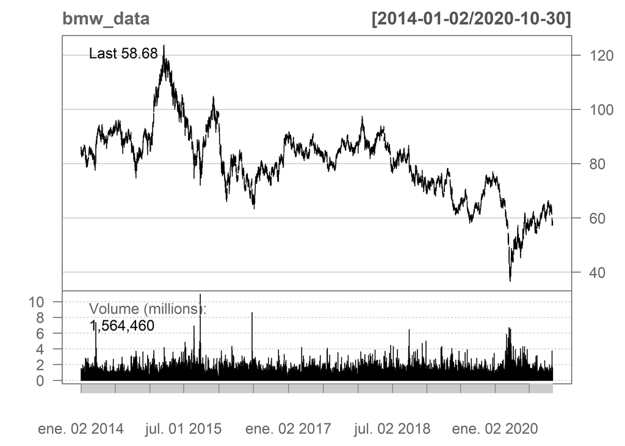

```r
  # Para visualizar la cotización de los activos utilizaremos la función barChart()

  # BMW:
barChart(bmw_data, theme = "white.mono")
```

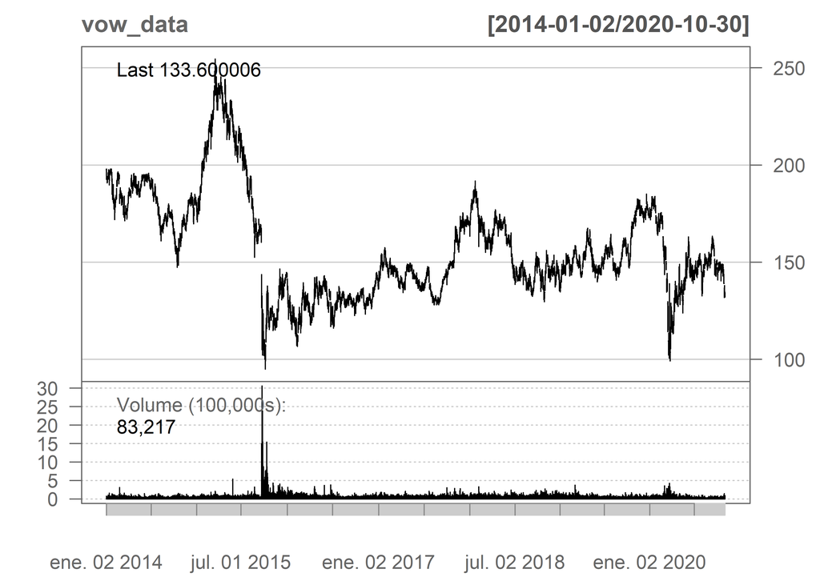

```r
  # Volkswagen:
barChart(vow_data, theme = "white.mono")
```

En el gráfico de Volkswagen, podemos ver claramente el efecto del **diseslgate**: *En septiembre de 2015 salió a la luz que Volkswagen había instalado ilegalmente un software para alterar los resultados de los controles técnicos de emisiones contaminantes en 11 millones de automóviles con motor diésel, vendidos entre 2009 y 2015. Como resultado de este fraude, sus motores habían superado con creces los estándares de la Agencia de Protección Ambiental de Estados Unidos (EPA). Los vehículos implicados emiten en condiciones reales hasta 40 veces el límite legal de óxidos de nitrógeno.*

## CAUSAL IMPACT

En nuestro caso tenemos distintos precios en ambos datasets, lo que haremos será eliminar los nulos para no obtener fallos y trabajaremos sobre el precio ajustado

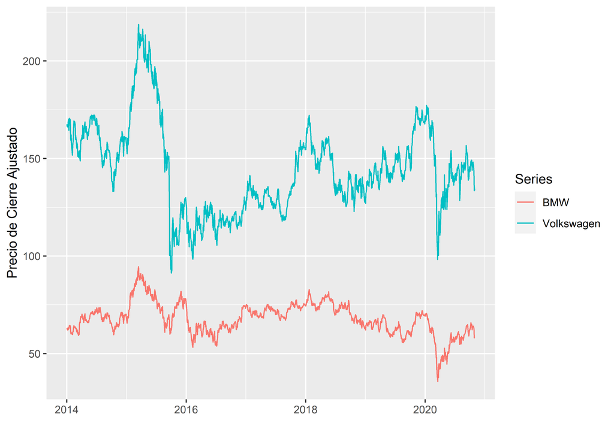

```r
  # Unimos los dos dtasets con los precios ajustados
serie <- cbind(bmw_data$BMW.DE.Adjusted, vow_data$VOW.DE.Adjusted)

  # Eliminamos los na en ambas series
serie <- na.exclude(serie)

  # Comprobamos el resultado mediante un autoplot
colnames(serie) <- c("BMW", "Volkswagen")
autoplot(serie, facet = NULL) + xlab("") + ylab("Precio de Cierre Ajustado")
```

En este caso podemos visualizar ambos precios de cierre ajustados, y cómo en 2015 tiene el efecto el dieselgate sobre Volkswagen, por lo tanto, tendremos que definir el periodo pre-dieselgate y el periodo post:

Como podemos observar el efecto del dieselgate se produjo desde mediados de marzo del 2015 hasta principios de octubre de ese mismo año. Sin emabrgo el escándolo no salió a la luz hasta mediados de septiembre, en concreto el 18, por lo que usaremos esa fecha como punto de inflexión.

```r
  # Definimos el periodo pre-dieselgate y post
pre_dieselgate <- as.Date(c("2014-01-02", "2015-09-18"))
post_dieselgate <- as.Date(c("2015-09-21", "2020-10-30"))
```

### Estimación Volkswagen

```r
  # Estimamos el modelo con causalImpact
volkswagen_causal <- CausalImpact(serie[, 2], pre.period = pre_dieselgate,  post.period = post_dieselgate)

  # Resumen y plots
summary(volkswagen_causal)
```

```
## Posterior inference {CausalImpact}
##
##                          Average       Cumulative
## Actual                   136           176108
## Prediction (s.d.)        147 (48)      190333 (62214)
## 95% CI                   [53, 244]     [69305, 316775]
##
## Absolute effect (s.d.)   -11 (48)      -14226 (62214)
## 95% CI                   [-109, 82]    [-140668, 106803]
##
## Relative effect (s.d.)   -7.5% (33%)   -7.5% (33%)
## 95% CI                   [-74%, 56%]   [-74%, 56%]
##
## Posterior tail-area probability p:   0.40729
## Posterior prob. of a causal effect:  59%
##
## For more details, type: summary(impact, "report")
```

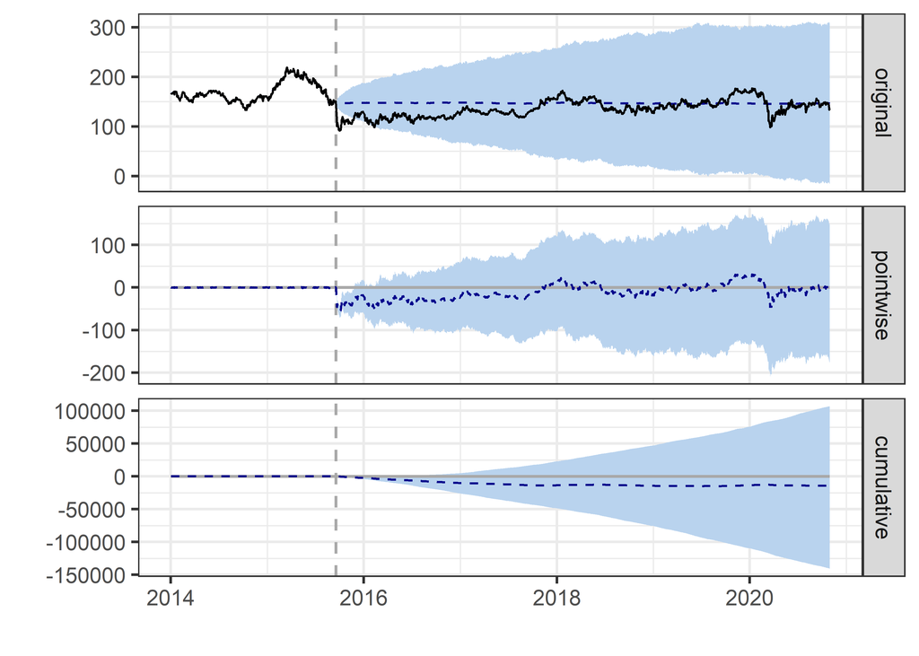

```r
plot(volkswagen_causal)
```

```r
  # Informe automático
summary(volkswagen_causal, "report")
```

```
## Analysis report {CausalImpact}
##
##
## During the post-intervention period, the response variable had an average value of approx. 135.89. In the absence of an intervention, we would have expected an average response of 146.86. The 95% interval of this counterfactual prediction is [53.48, 244.43]. Subtracting this prediction from the o…
##
## Summing up the individual data points during the post-intervention period (which can only sometimes be meaningfully interpreted), the response variable had an overall value of 176.11K. Had the intervention not taken place, we would have expected a sum of 190.33K. The 95% interval of this predicti…
##
## The above results are given in terms of absolute numbers. In relative terms, the response variable showed a decrease of -7%. The 95% interval of this percentage is [-74%, +56%].
##
## This means that, although it may look as though the intervention has exerted a negative effect on the response variable when considering the intervention period as a whole, this effect is not statistically significant, and so cannot be meaningfully interpreted. The apparent effect could be the re…
##
## The probability of obtaining this effect by chance is p = 0.407. This means the effect may be spurious and would generally not be considered statistically significant.
```

*Durante el período posterior a la intervención, la variable de respuesta tuvo un valor promedio de aprox. 135,89. En ausencia de una intervención, hubiéramos esperado una respuesta promedio de 146,86. El intervalo del 95% de esta predicción contrafactual es [53,51, 244,38]. Al restar esta predicción de la respuesta observada se obtiene una estimación del efecto causal que tuvo la intervención sobre la variable de respuesta. Este efecto es -10,98 con un intervalo del 95% de [-108,50, 82,38]. Para una discusión sobre la importancia de este efecto, vea a continuación.*

*Al resumir los puntos de datos individuales durante el período posterior a la intervención (que solo a veces se puede interpretar de manera significativa), la variable de respuesta tuvo un valor general de 176.11K. Si la intervención no hubiera tenido lugar, hubiéramos esperado una suma de 190,33 mil. El intervalo del 95% de esta predicción es [69,35 K, 316,72 K].*

*Los resultados anteriores se dan en términos de números absolutos. En términos relativos, la variable respuesta mostró una disminución del -7%. El intervalo del 95% de este porcentaje es [-74%, + 56%].*

*Esto significa que, aunque puede parecer que la intervención ha ejercido un efecto negativo sobre la variable de respuesta cuando se considera el período de intervención en su conjunto, este efecto no es estadísticamente significativo y, por lo tanto, no puede interpretarse de manera significativa. El efecto aparente podría ser el resultado de fluctuaciones aleatorias que no están relacionadas con la intervención. Este suele ser el caso cuando el período de intervención es muy largo e incluye gran parte del tiempo cuando el efecto ya ha desaparecido. También puede ocurrir cuando el período de intervención es demasiado corto para distinguir la señal del ruido. Finalmente, no encontrar un efecto significativo puede ocurrir cuando no hay suficientes variables de control o cuando estas variables no se correlacionan bien con la variable de respuesta durante el período de aprendizaje.*

*La probabilidad de obtener este efecto por azar es p = 0,407. Esto significa que el efecto puede ser falso y, en general, no se consideraría estadísticamente significativo.*

### Estimación BMW

```r
  # Estimamos el modelo con causalImpact
bmw_causal <- CausalImpact(serie[, 1], pre.period = pre_dieselgate,  post.period = post_dieselgate)

  # Resumen y plots
summary(bmw_causal)
```

```
## Posterior inference {CausalImpact}
##
##                          Average       Cumulative
## Actual                   67            86292
## Prediction (s.d.)        68 (21)       88543 (26792)
## 95% CI                   [28, 110]     [36121, 143180]
##
## Absolute effect (s.d.)   -1.7 (21)     -2250.9 (26792)
## 95% CI                   [-44, 39]     [-56888, 50172]
##
## Relative effect (s.d.)   -2.5% (30%)   -2.5% (30%)
## 95% CI                   [-64%, 57%]   [-64%, 57%]
##
## Posterior tail-area probability p:   0.45807
## Posterior prob. of a causal effect:  54%
##
## For more details, type: summary(impact, "report")
```

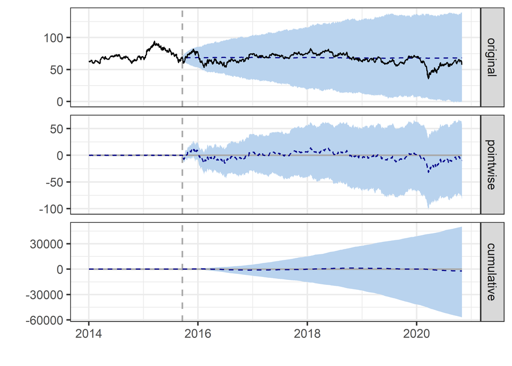

```r
plot(bmw_causal)
```

```r
  # Informe automático
summary(bmw_causal, "report")
```

```
## Analysis report {CausalImpact}
##
##
## During the post-intervention period, the response variable had an average value of approx. 66.58. In the absence of an intervention, we would have expected an average response of 68.32. The 95% interval of this counterfactual prediction is [27.87, 110.48]. Subtracting this prediction from the obs…
##
## Summing up the individual data points during the post-intervention period (which can only sometimes be meaningfully interpreted), the response variable had an overall value of 86.29K. Had the intervention not taken place, we would have expected a sum of 88.54K. The 95% interval of this prediction…
##
## The above results are given in terms of absolute numbers. In relative terms, the response variable showed a decrease of -3%. The 95% interval of this percentage is [-64%, +57%].
##
## This means that, although it may look as though the intervention has exerted a negative effect on the response variable when considering the intervention period as a whole, this effect is not statistically significant, and so cannot be meaningfully interpreted. The apparent effect could be the re…
##
## The probability of obtaining this effect by chance is p = 0.458. This means the effect may be spurious and would generally not be considered statistically significant.
```

*Durante el período posterior a la intervención, la variable de respuesta tuvo un valor promedio de aprox. 66,58. En ausencia de una intervención, hubiéramos esperado una respuesta promedio de 68,32. El intervalo del 95% de esta predicción contrafactual es [27,88, 110,47]. Al restar esta predicción de la respuesta observada se obtiene una estimación del efecto causal que tuvo la intervención sobre la variable de respuesta. Este efecto es -1,74 con un intervalo del 95% de [-43,89, 38,71]. Para una discusión sobre la importancia de este efecto, vea a continuación.*

*Al resumir los puntos de datos individuales durante el período posterior a la intervención (que solo a veces se puede interpretar de manera significativa), la variable de respuesta tuvo un valor general de 86.29K. Si la intervención no hubiera tenido lugar, hubiéramos esperado una suma de 88.54K. El intervalo del 95% de esta predicción es [36,13 K, 143,17 K].*

*Los resultados anteriores se dan en términos de números absolutos. En términos relativos, la variable respuesta mostró una disminución del -3%. El intervalo del 95% de este porcentaje es [-64%, + 57%].*

*Esto significa que, aunque puede parecer que la intervención ha ejercido un efecto negativo sobre la variable de respuesta cuando se considera el período de intervención en su conjunto, este efecto no es estadísticamente significativo y, por lo tanto, no puede interpretarse de manera significativa. El efecto aparente podría ser el resultado de fluctuaciones aleatorias que no están relacionadas con la intervención. Este suele ser el caso cuando el período de intervención es muy largo e incluye gran parte del tiempo cuando el efecto ya ha desaparecido. También puede ocurrir cuando el período de intervención es demasiado corto para distinguir la señal del ruido. Finalmente, no encontrar un efecto significativo puede ocurrir cuando no hay suficientes variables de control o cuando estas variables no se correlacionan bien con la variable de respuesta durante el período de aprendizaje.*

*La probabilidad de obtener este efecto por azar es p = 0,458. Esto significa que el efecto puede ser falso y, en general, no se consideraría estadísticamente significativo.*